# Health-System Access Barriers to Care-Seeking Among Women Aged 15–49 Years in Cote d’Ivoire: Analysis of the Demographic and Health (DHS) Survey

Hafsa Khalid Sharif

# 1 Introduction

## 1.1 Background

Cote d’Ivoire is a lower-middle-income country in West Africa. Its population has grown rapidly, from an estimated 22.8 million in 2012 to approximately 33.5 million today. Although the country has made considerable progress in strengthening its healthcare system, substantial disparities in healthcare access remain, particularly between urban and rural populations and across socioeconomic groups. Identifying barriers that prevent women from seeking healthcare is important for achieving universal health coverage and improving health outcomes.

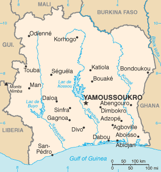

Cote d’Ivoire Map

## 1.2 Healthcare system in Cote d’Ivoire

The healthcare system in Cote d’Ivoire combines public, private, and non-profit facilities, though it continues to face structural challenges following past political crises and resource limitations.

## 1.3 Importance of DHS Women’s Recode Dataset (DHS) used

The Demographic and Health Surveys (DHS) Individual (Women’s) Recode dataset is a crucial global resource for measuring and analyzing women’s health, empowerment, and demographic trends. For Cote d’Ivoire, the DHS dataset provides critical, nationally representative data on women’s health, reproductive knowledge, empowerment, and living conditions to guide public health policies and development goals.

# 2 Study Rationale and Aim

Access to healthcare is a fundamental determinant of population health and an important component of Universal Health Coverage. Women living in low- and middle-income countries often experience multiple barriers to obtaining timely healthcare, including financial limitations, transportation difficulties, long travel distances, and limited decision-making autonomy. Identifying these barriers and the population groups most affected can help policymakers target interventions that improve equitable healthcare access.

This study examines self-reported healthcare access barriers among women aged 15–49 years in Cote d’Ivoire using data from the Demographic and Health Survey (DHS). Specifically, the study investigates how reported barriers vary according to age group, place of residence, educational levels, household wealth, marital status, and employment status.

# 3 Research Question

This study addressed the following research questions:

1. What proportion of women aged 15–49 years reported major barriers to accessing healthcare?

2. Which healthcare access barriers were most frequently reported as major problems?

3. How did reported healthcare access barriers vary according to age group, place of residence, educational levels, household wealth, marital status, and employment status?

# 4 Methodology

## 4.1 Study Design

This study employed a cross-sectional descriptive design using secondary data from the Cote d’Ivoire Demographic and Health Survey (DHS) Women’s Recode dataset. The analysis focused on women aged 15–49 years interviewed during the survey and examined self-reported barriers to accessing healthcare.

## 4.2 Data Source

Demographic and Health Survey (DHS) Women’s Recode dataset obtained from [DHS Dataset: All Countries](https://drive.google.com/drive/folders/1J0gw4qpfbB8bYFbXx8QcsQEWgJSVwp_P).

The primary data file (.DTA) was imported into R using the haven package.

The accompanying DHS documentation files were consulted during variable selection.

The .MAP file provides descriptions and coding information for survey variables, while the .DO file was used to confirm the exact variable names available in the dataset.

DHS documentation presents variables in uppercase (for example V467A); however, the actual dataset stores variables in lowercase (v467a); thus, all variable selection was performed using lowercase names consistent with the imported dataset.

## 4.3 Study Variables

Outcome Variables:

The Five DHS Variables Representing Barriers to Health-System Access and Care-Seeking:

- Problem obtaining permission for treatment.
- Problem obtaining money for treatment.
- Distance to facility is a problem.
- Not wanting to go alone.
- Concern no female provider available.

Each variable was analysed using responses identifying the barrier as a “big problem.”

Explanatory Variables:

The Explanatory Variables included: Age, Highest Educational Level, Wealth, Place of Residence, Marital Status, and Employment Status.

## 4.4 Data Wrangling and Manipulation

Data cleaning and preparation were performed using the tidyverse package. Variables required for the study were selected from the original dataset, and DHS labelled variables were converted to factor variables using the haven package.

Age was categorized into four groups (15–19, 20–29, 30–39, and 40–49 years).

The five healthcare access variables were reshaped into long format using pivot_longer() to facilitate descriptive analyses and graphical visualisation.

## 4.5 Statistical Analysis

Descriptive statistics were used throughout the analysis. Categorical variables were summarised using frequencies and percentages. Socio-demographic characteristics of respondents were presented in Table 1. The prevalence of each healthcare access barrier reported as a “big problem” were summarised in Table 2.

Bar charts and line graphs were produced using the ggplot2 package to compare reported barriers across age group, place of residence, educational levels, household wealth, marital status, and employment status. All analyses were conducted in R (version 4.4.1).

# 5 Results

A total of 10060 women aged 15–49 years were included in this analysis. The largest age group was 20–29 years (38%), followed by 30–39 years (26%), 15–19 years (20%), and 40–49 years (16%).

Full socio-demographic characteristics of the sample are presented in Table 1, and the prevalence of each healthcare access barrier is presented in Table 2.

## 5.1 Tables:

Table 1. Socio-demographic characteristics of women aged 15–49 years in Cote d'Ivoire.

| Characteristic | N = 10,0601 |
| --- | --- |
| Age Groups |  |
| 15-19 | 1,997 (20%) |
| 20-29 | 3,849 (38%) |
| 30-39 | 2,620 (26%) |
| 40-49 | 1,594 (16%) |
| Place of Residence |  |
| urban | 4,595 (46%) |
| rural | 5,465 (54%) |
| Highest Educational Level |  |
| no education | 5,744 (57%) |
| primary | 2,347 (23%) |
| secondary | 1,740 (17%) |
| higher | 229 (2.3%) |
| Household Wealth Index |  |
| poorest | 1,978 (20%) |
| poorer | 1,926 (19%) |
| middle | 1,926 (19%) |
| richer | 2,055 (20%) |
| richest | 2,175 (22%) |
| Marital Status |  |
| never in union | 2,949 (29%) |
| married | 4,354 (43%) |
| living with partner | 2,099 (21%) |
| widowed | 225 (2.2%) |
| divorced | 84 (0.8%) |
| no longer living together/separated | 349 (3.5%) |
| Currently Employed |  |
| no | 3,231 (32%) |
| yes | 6,793 (68%) |
| Unknown | 36 |

1n (%)

Table 2. Frequency and prevalence of reported healthcare access barriers among women aged 15–49 years.

| Type of Healthcare Access Barrier | Number of Women Reporting this Barrier as Big Problem | Percentage of Women Reporting this Barrier as Big Problem |
| --- | --- | --- |
| Money for treatment | 6,890 | 68.5 |
| Distance to facility | 4,102 | 40.8 |
| Permission for Treatment | 2,577 | 25.6 |
| Not wanting to go alone | 1,528 | 15.2 |
| No female provider | 1,508 | 15.0 |

Among women aged 15–49 years in Cote d’Ivoire, the most commonly reported healthcare access barrier was obtaining money for treatment, with 68.5% of women identifying it as a big problem. Distance to a health facility was the second most frequently reported barrier (40.8%), followed by difficulty obtaining permission for treatment (25.6%). Barriers related to not wanting to go alone and lack of a female provider were less commonly reported (15.2% and 15.0%, respectively).

## 5.2 Figures:

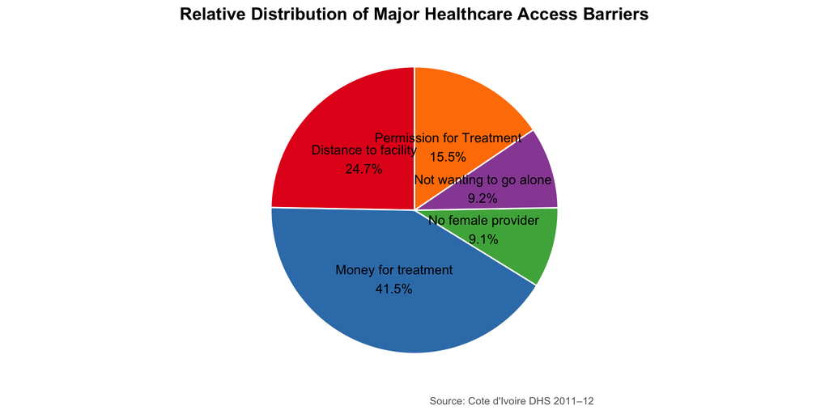

Percentages in figure 1 represent the proportion of all reported major barriers and do not correspond to the prevalence estimates presented in Table 2.

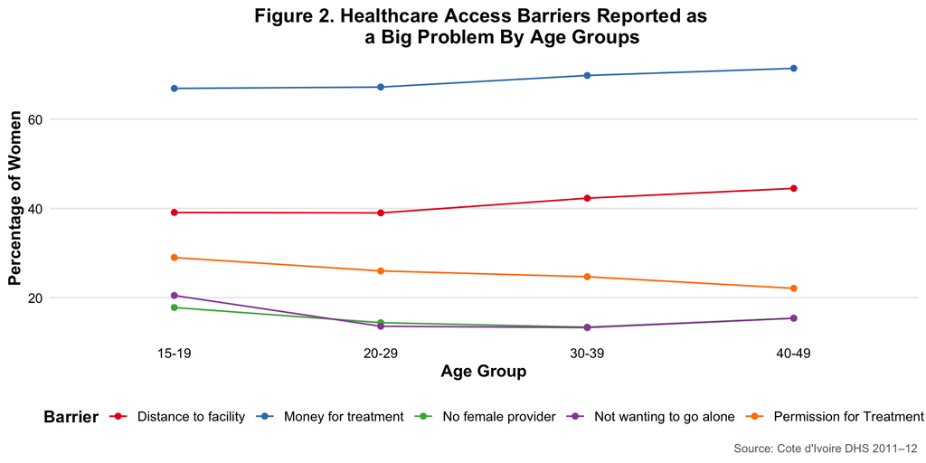

Figure 2 illustrates that obtaining money for treatment followed by distance to facility were the two most frequently reported barriers in every age group, and both increased slightly with age. In contrast, obtaining permission for treatment was reported more often by the youngest women (15–19 years) than by older age groups. This could be explained by the fact that younger and more often unmarried women needing permission from a parent or partner before seeking care.

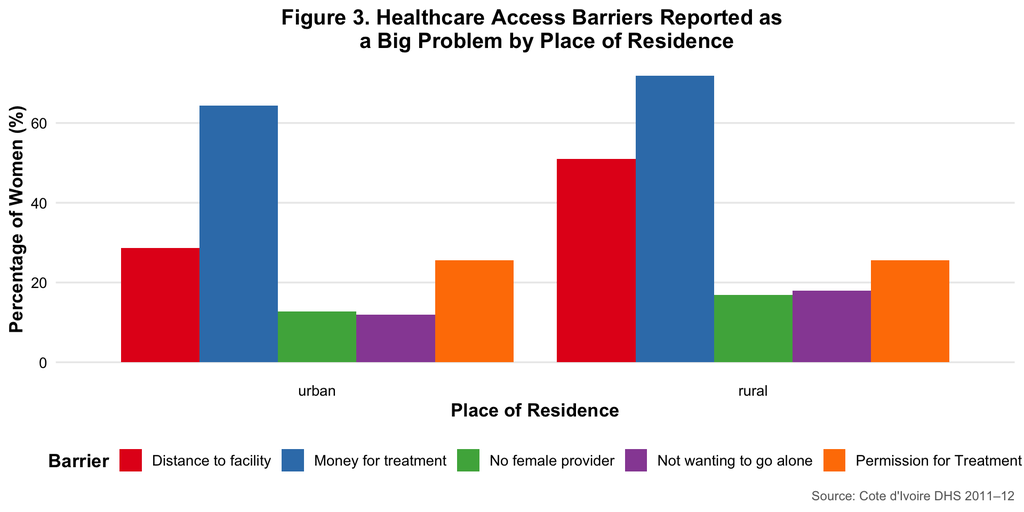

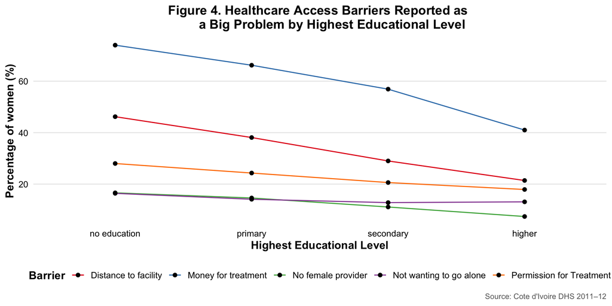

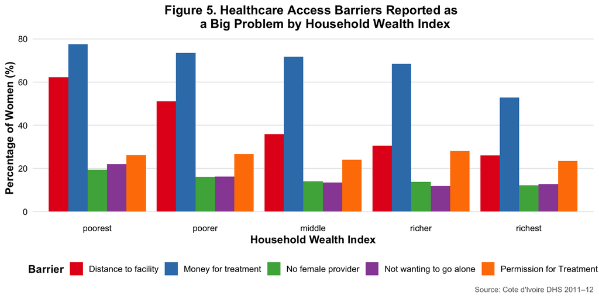

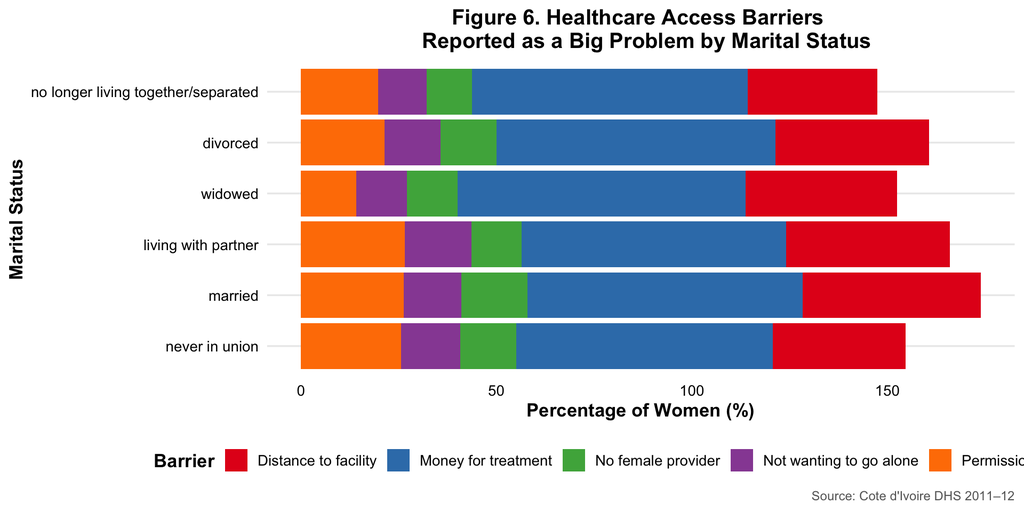

Figure 6 demonstrates that obtaining money for treatment was the leading barrier across all marital status categories, with differences between groups smaller than those seen for wealth or education.

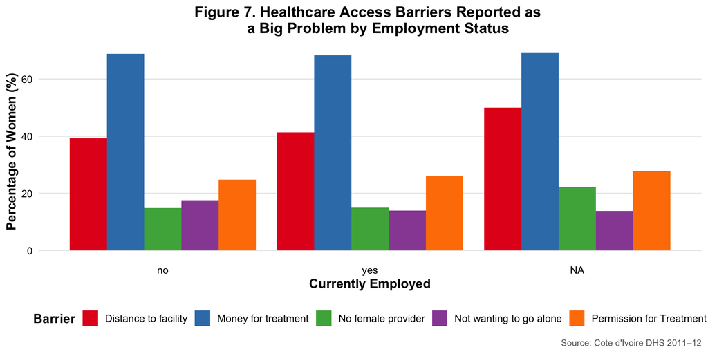

Figure 7 shows that financial constraints were the most frequently reported healthcare access barrier regardless of employment status, with approximately 69–70% of women identifying obtaining money for treatment as a major problem. Distance to a health facility was the second most common barrier across all employment groups, affecting around 40–50% of respondents. Women with missing employment information (NA) generally reported the highest prevalence of financial and distance-related barriers, whereas differences between currently employed and unemployed women were relatively small.

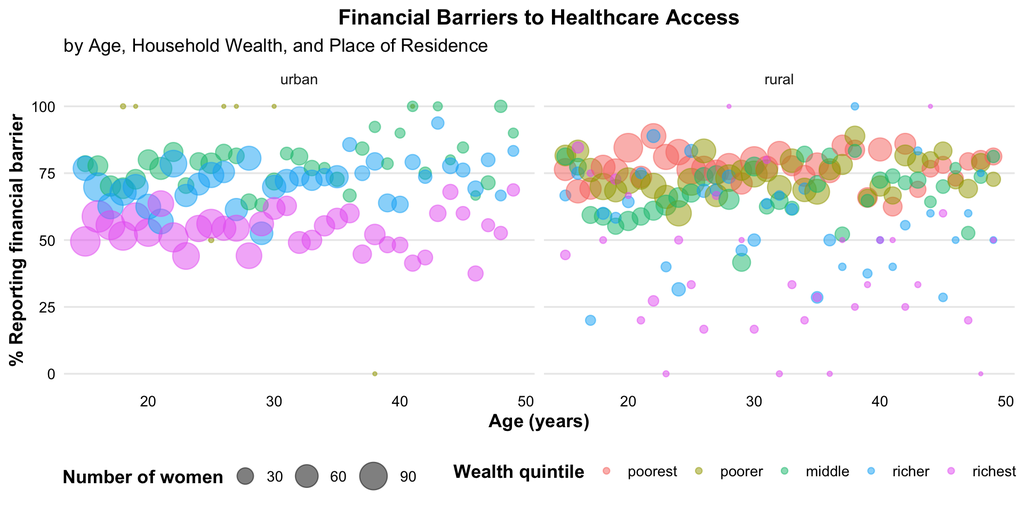

The bubble plot (figure 8) above illustrates the proportion of women reporting obtaining money for treatment as a major healthcare access barrier across age, household wealth, and place of residence. Financial barriers remained consistently high across all age groups, particularly among women from the poorest and poorer wealth quintiles. In rural areas, women from lower wealth quintiles generally reported a higher prevalence of financial barriers than women from wealthier households, with many estimates exceeding 70%. In contrast, women in the richest wealth quintile reported comparatively lower percentages across both urban and rural settings. Bubble size indicates the number of women within each age and wealth category, showing that larger respondent groups were concentrated among younger women.

# 6 Conclusion and Discussion:

In conclusion, this study examined self-reported healthcare access barriers among women aged 15–49 years in Cote d’Ivoire using nationally representative DHS data.

Financial barriers were the most commonly reported obstacle to healthcare access, followed by geographical barriers such as distance to healthcare facilities.

Women living in rural areas and those from poorer households consistently reported greater healthcare access challenges.

These findings highlight persistent inequalities in healthcare access and support the need for targeted interventions aimed at reducing financial and geographical barriers while strengthening equitable access to health services.

These findings are consistent with broader evidence from DHS analyses in sub-Saharan Africa, where financial constraints and geographic accessibility have frequently been reported as major barriers to healthcare utilisation.

## 6.1 Strengths and Limitations

A major strength of this study is the use of nationally representative DHS data, which provides a large sample size and standardised measures of healthcare access barriers among women in Cote d’Ivoire.

The analysis also examined multiple socio-demographic factors, allowing comparison of healthcare access challenges across different population groups.

However, this study has several limitations:

- The cross-sectional design of the DHS prevents causal conclusions regarding the relationship between socio-demographic characteristics and healthcare access barriers.
- The analysis relied on self-reported responses, which may be influenced by recall or reporting bias.
- The estimates were also not adjusted using DHS sampling weights, meaning results may differ slightly from official DHS estimates.
- Finally, only barriers available within the DHS dataset were assessed, and other factors were not examined.